# Bluefish ESP indicator figures

Abigail Tyrell & Samantha Werner

26 Aug 2022

This document contains in-progress bluefish ESP figures. Recompile the .Rmd to view the most recent figures.

# 1 Background

## 1.1 Socioeconomic background

##### Figure 1

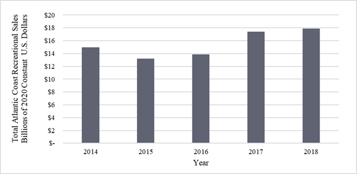

Figure 1. Figure aa. Total annual recreational sales from Atlantic coastal states over 2014-2018 in billions of 2020 constant U.S. Dollars. Data obtained from the Fisheries Economics of the United States Reports (2014-2018). Values were adjusted using the Gross Domestic Product Implicit Price Deflator.

##### Figure 2

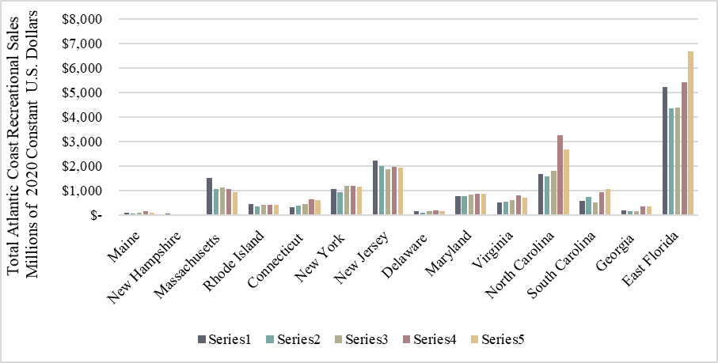

Figure 2. Figure bb. Total annual recreational sales by Atlantic Coastal state from 2014-2018 in millions of 2020 constant U.S. Dollars. Data obtained from the Fisheries Economics of the United States. Values were adjusted using the Gross Domestic Product Implicit Price Deflator.

##### Figure 3

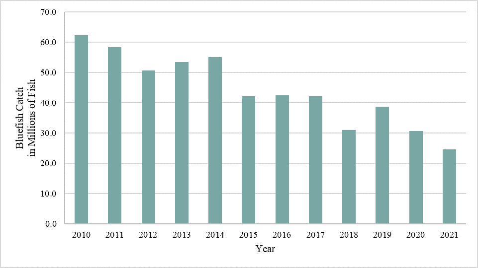

Figure 3. Figure cc Figure 3. Recreational bluefish catch from Atlantic Coastal states over 2010-2021. Data acquired from the Marine Recreational Information Program (MRIP) query tool in January 2022.

##### Figure 4

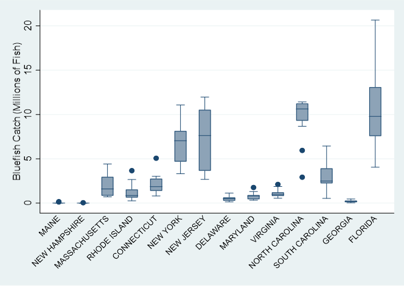

Figure 4. Figure dd. Recreational bluefish catch box plots from 2010-2021 by Atlantic coastal states. Data retrieved from the Marine Recreational Information Program (MRIP) query tool in January 2022.

##### Figure 5

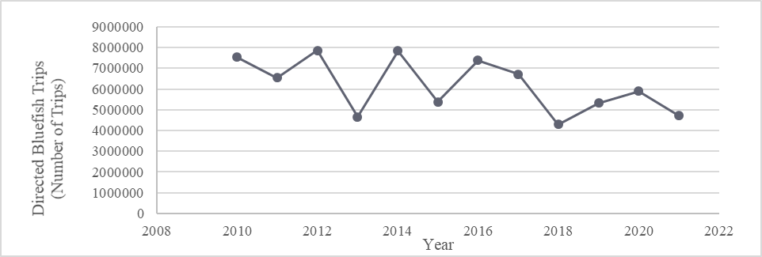

Figure 5. Figure ee. Number of directed recreational bluefish trips from Atlantic coastal states (2010-2021). Data retrieved from the Marine Recreational Information Program (MRIP) query tool in January 2022.

##### Figure 6

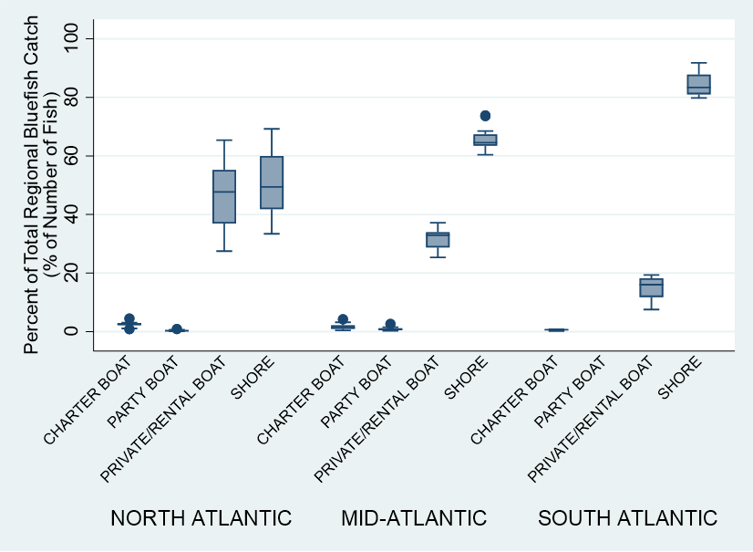

Figure 6. Figure ff. Proportion of regional recreational bluefish catch in number of fish by fishing mode (2010-2021). Data retrieved from the Marine Recreational Information Program (MRIP) query tool in January 2022.

##### Figure 7

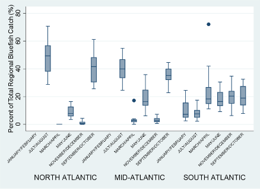

Figure 7. Figure gg. Proportion of total recreational bluefish catch by month grouping and region (2010-2021). Data retrieved from the Marine Recreational Information Program (MRIP) query tool in January 2022

##### Figure 8

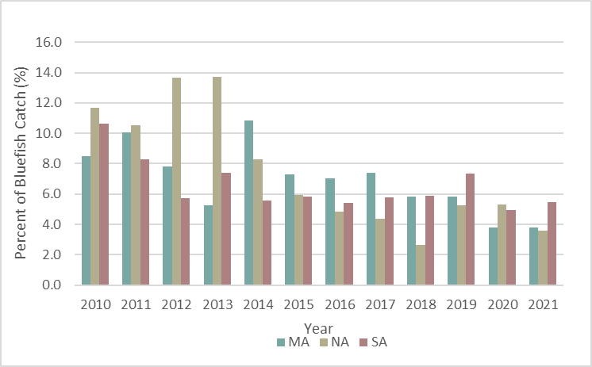

Figure 8. Figure hh. Recreational bluefish catch as a percent of total recreational catch by region over 2010-2021. Data retrieved from the Marine Recreational Information Program (MRIP) query tool in January 2022.

##### Figure 9

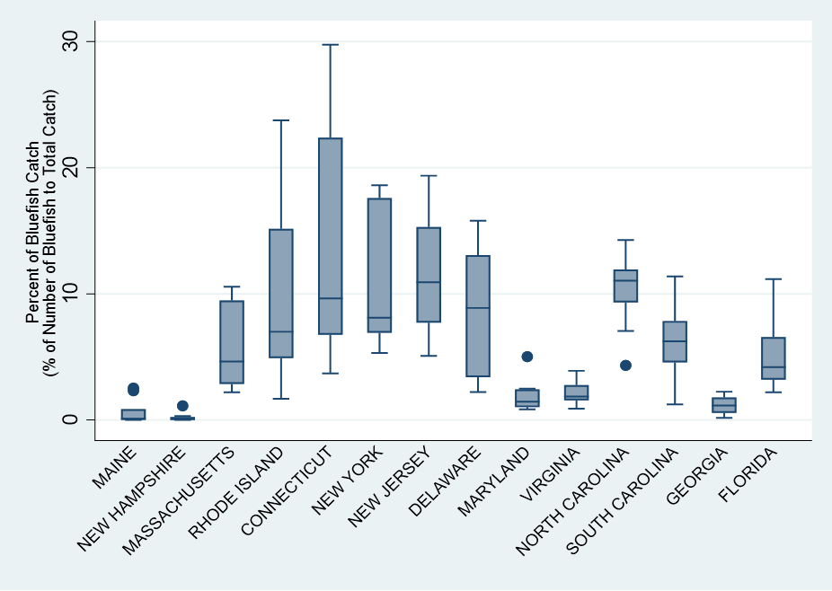

Figure 9. Figure ii. Box plots of recreational bluefish catch as a percent of total recreational catch by sate over 2010-2021. Data source: Data retrieved from the Marine Recreational Information Program (MRIP) query tool in January 2022. Conneticute has the hightes percent of bluefish catch relative to other sepices and New Hampshire the lowest.

# 2 Environment and distribution

## 2.1 Federal surveys

### 2.1.1 EcoMon/MARMAP

#### 2.1.1.1 Eggs

##### Figure 10

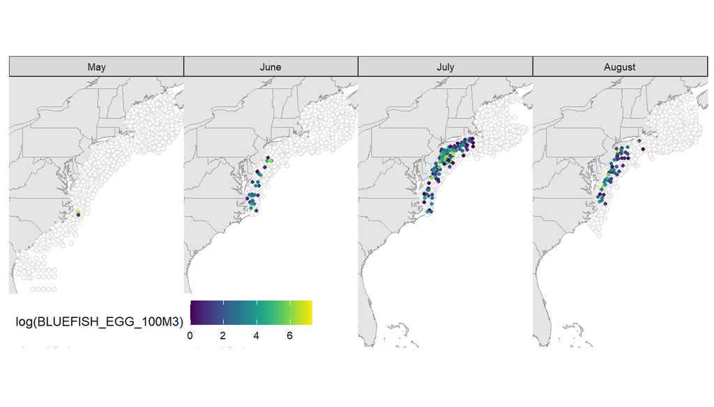

##### Summary table

| MONTH | n_tows | n_positive_tow | total_n | n_per_tow | n_years | n_positive_years | mean_surface_temp | n_temp | mean_surface_sal | n_sal |
| --- | --- | --- | --- | --- | --- | --- | --- | --- | --- | --- |
| 5 | 1681 | 2 | 876.0 | 0.5 | 12 | 2 | 19.9 | 876.0 | 35.3 | 2.5 |
| 6 | 996 | 28 | 1636.4 | 1.6 | 10 | 4 | 20.4 | 1636.4 | 31.6 | 551.3 |
| 7 | 966 | 132 | 10321.3 | 10.7 | 11 | 8 | 21.5 | 10321.3 | 31.0 | 3016.7 |
| 8 | 1183 | 53 | 3095.6 | 2.6 | 11 | 8 | 24.4 | 3095.6 | 32.6 | 32.3 |

#### 2.1.1.2 Larvae

##### Figure 11

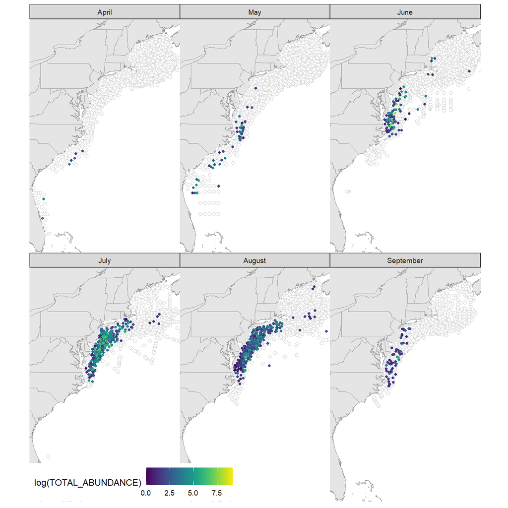

##### Summary table

| MONTH | n_tows | n_positive_tow | total_n | n_per_tow | n_years | n_positive_years | mean_surface_temp | n_temp | mean_surface_sal | n_sal |
| --- | --- | --- | --- | --- | --- | --- | --- | --- | --- | --- |
| 1 | 1789 | 1 | 2.2 | 0.0 | 26 | 1 | NA | NA | NA | NA |
| 4 | 3266 | 13 | 260.3 | 0.1 | 44 | 1 | NA | NA | NA | NA |
| 5 | 3477 | 105 | 11913.1 | 3.4 | 38 | 11 | 21.9 | 10285.5 | 31.1 | 10285.5 |
| 6 | 3083 | 218 | 15961.1 | 5.2 | 34 | 17 | 22.3 | 9463.1 | 31.0 | 9919.8 |
| 7 | 1430 | 1010 | 46984.9 | 32.9 | 21 | 17 | 23.3 | 5376.5 | 31.7 | 5376.5 |
| 8 | 3011 | 915 | 18413.0 | 6.1 | 31 | 27 | 24.5 | 7522.9 | 31.6 | 7520.7 |
| 9 | 2210 | 96 | 631.5 | 0.3 | 43 | 19 | 23.8 | 564.1 | 32.2 | 564.1 |

### 2.1.2 NMFS bottom trawl

##### Figure 12

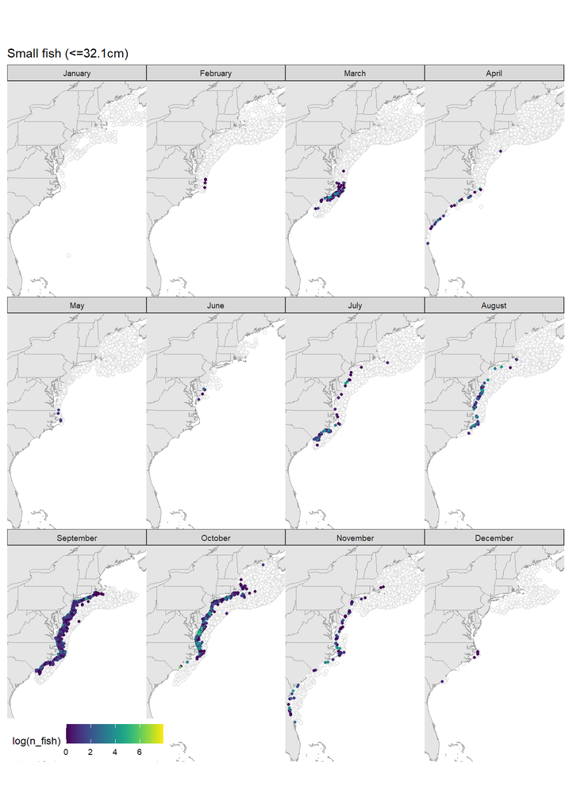

##### Figure 13

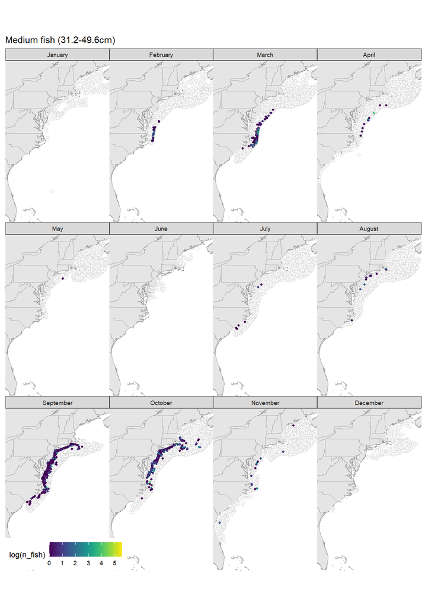

##### Figure 14

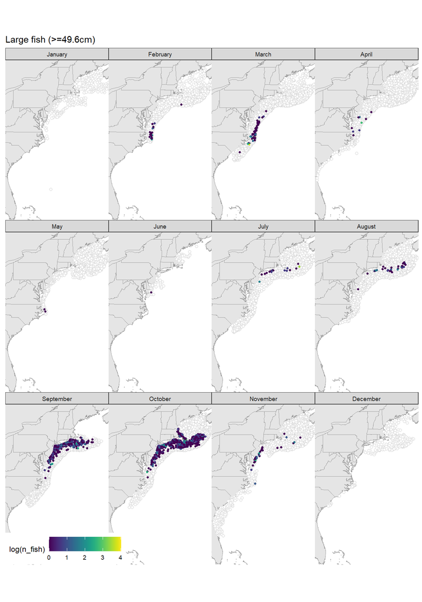

##### Summary table

Small bluefish

| MONTH | n_tows | total_n | n_per_tow | mean_surface_temp | n_temp | mean_surface_sal | n_sal |
| --- | --- | --- | --- | --- | --- | --- | --- |
| 2 | 2381 | 4 | 0.0 | 12.2 | 3 | 34.5 | 3 |
| 3 | 8746 | 1004 | 0.1 | 11.7 | 993 | 32.9 | 526 |
| 4 | 8252 | 201 | 0.0 | 16.9 | 199 | 35.1 | 95 |
| 5 | 1803 | 18 | 0.0 | 18.6 | 18 | NA | NA |
| 6 | 123 | 18 | 0.1 | 19.9 | 18 | NA | NA |
| 7 | 959 | 855 | 0.9 | 26.4 | 737 | NA | NA |
| 8 | 1366 | 1428 | 1.0 | 24.0 | 1353 | NA | NA |
| 9 | 7066 | 63043 | 8.9 | 21.5 | 51742 | 30.9 | 26324 |
| 10 | 8974 | 15737 | 1.8 | 18.8 | 12928 | 30.8 | 3676 |
| 11 | 3512 | 813 | 0.2 | 18.5 | 812 | 31.9 | 2 |
| 12 | 243 | 6 | 0.0 | 14.4 | 6 | NA | NA |

Medium bluefish

| MONTH | n_tows | total_n | n_per_tow | mean_surface_temp | n_temp | mean_surface_sal | n_sal |
| --- | --- | --- | --- | --- | --- | --- | --- |
| 2 | 2381 | 84 | 0.0 | 10.3 | 78 | 33.9 | 77 |
| 3 | 8746 | 625 | 0.1 | 11.6 | 480 | 34.3 | 378 |
| 4 | 8252 | 75 | 0.0 | 8.5 | 74 | 33.7 | 74 |
| 5 | 1803 | 1 | 0.0 | 8.4 | 1 | 32.7 | 1 |
| 7 | 959 | 8 | 0.0 | 24.6 | 8 | NA | NA |
| 8 | 1366 | 24 | 0.0 | 21.7 | 20 | NA | NA |
| 9 | 7066 | 1814 | 0.3 | 20.8 | 1584 | 31.1 | 1095 |
| 10 | 8974 | 742 | 0.1 | 17.8 | 645 | 31.7 | 197 |
| 11 | 3512 | 50 | 0.0 | 17.4 | 50 | NA | NA |

Large bluefish

| MONTH | n_tows | total_n | n_per_tow | mean_surface_temp | n_temp | mean_surface_sal | n_sal |
| --- | --- | --- | --- | --- | --- | --- | --- |
| 2 | 2381 | 62 | 0.0 | 10.2 | 61 | 33.7 | 59 |
| 3 | 8746 | 264 | 0.0 | 11.3 | 184 | 34.6 | 137 |
| 4 | 8252 | 29 | 0.0 | 10.3 | 27 | 33.8 | 23 |
| 5 | 1803 | 2 | 0.0 | 18.8 | 2 | NA | NA |
| 6 | 123 | 1 | 0.0 | 21.5 | 1 | NA | NA |
| 7 | 959 | 59 | 0.1 | 17.6 | 58 | NA | NA |
| 8 | 1366 | 70 | 0.1 | 17.2 | 70 | NA | NA |
| 9 | 7066 | 908 | 0.1 | 18.8 | 703 | 31.9 | 496 |
| 10 | 8974 | 1733 | 0.2 | 15.6 | 1507 | 32.2 | 718 |
| 11 | 3512 | 66 | 0.0 | 15.4 | 62 | NA | NA |

## 2.2 MRIP catch and CPUE

##### Figure 15

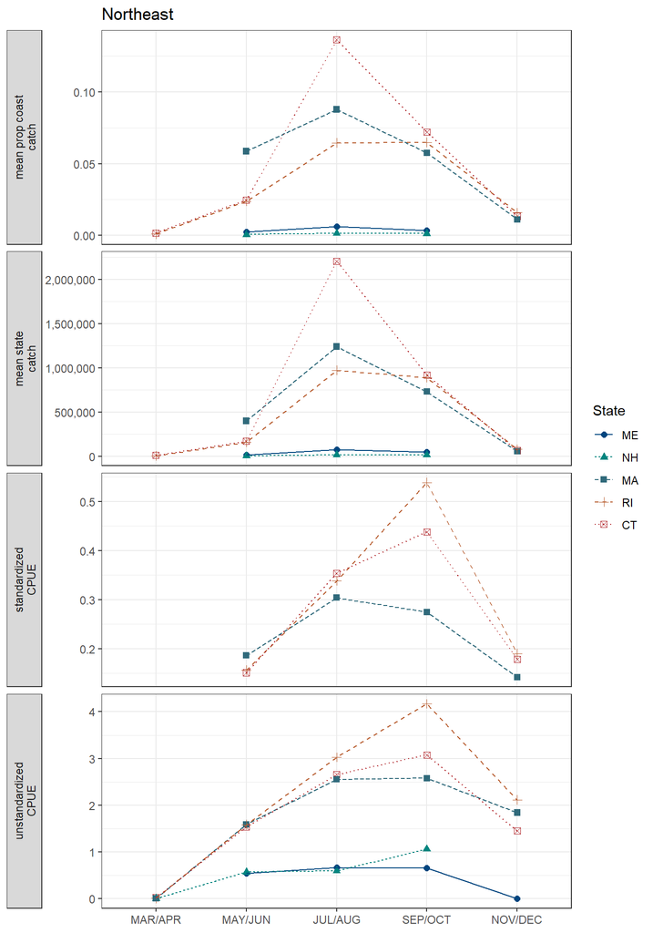

##### Figure 16

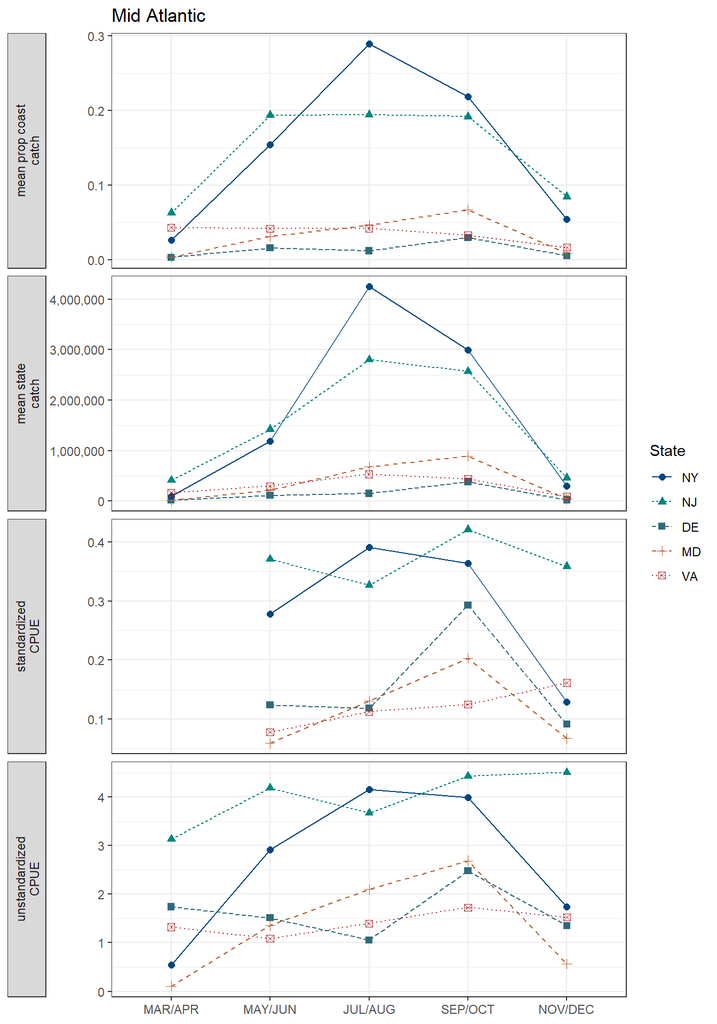

##### Figure 17

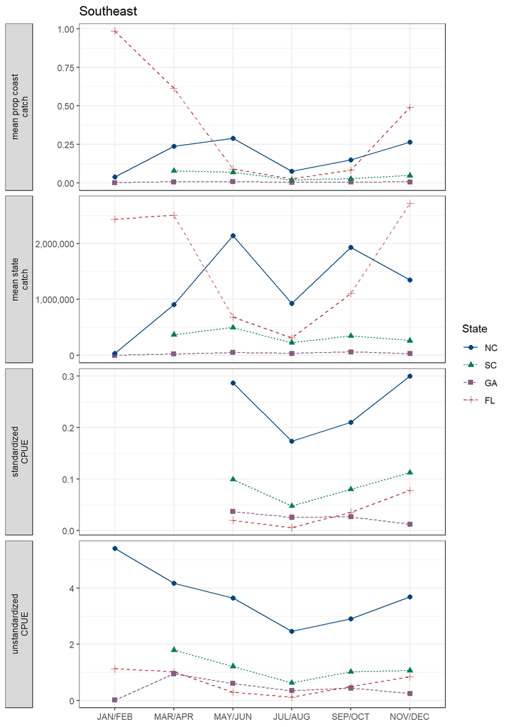

## 2.3 State surveys

### 2.3.1 Observations by month

##### Figure 18

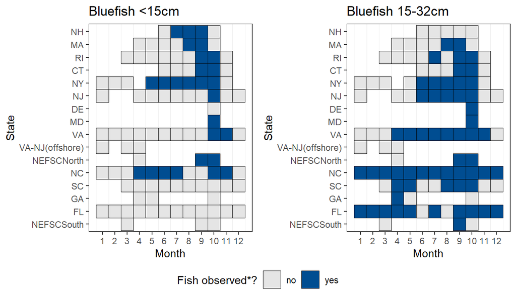

### 2.3.2 Select length cohort plots

#### 2.3.2.1 New Hampshire

##### Figure 19

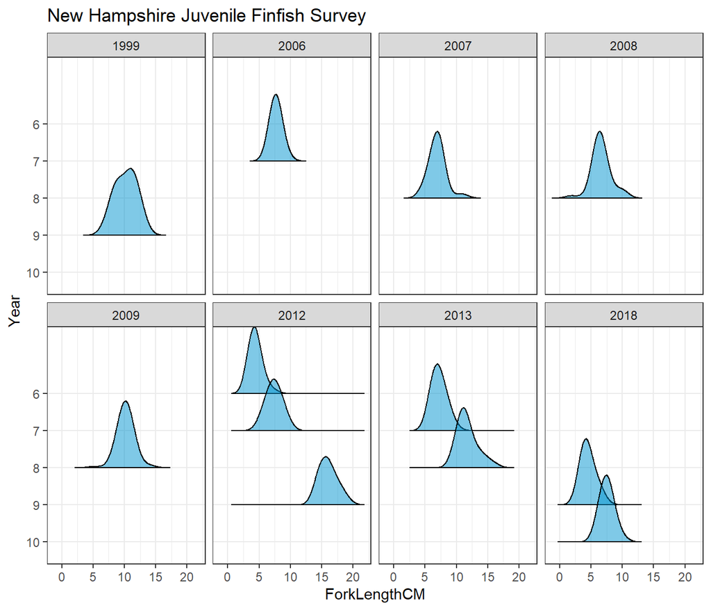

#### 2.3.2.2 New York (select years only)

##### Figure 20

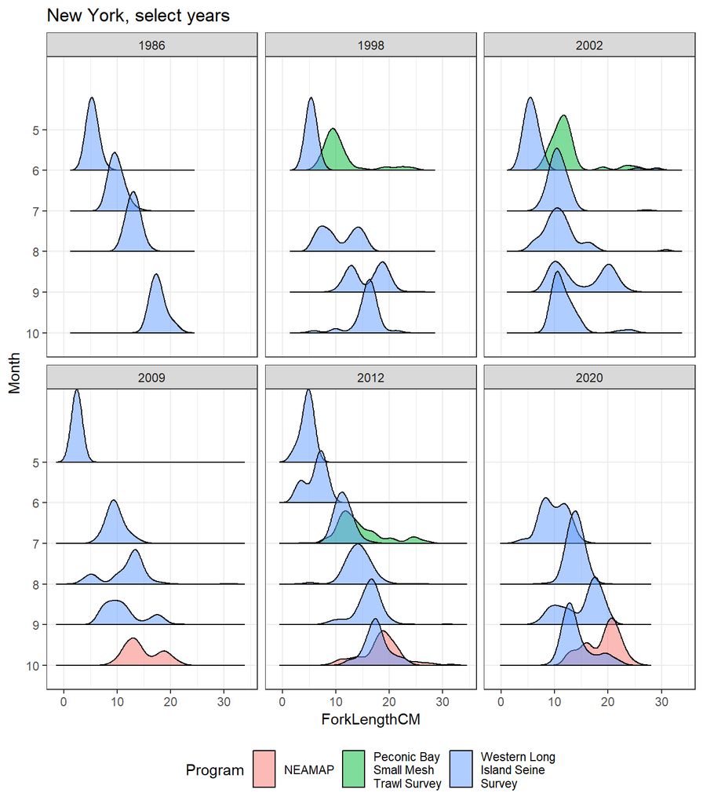

#### 2.3.2.3 North Carolina (select years only)

##### Figure 21

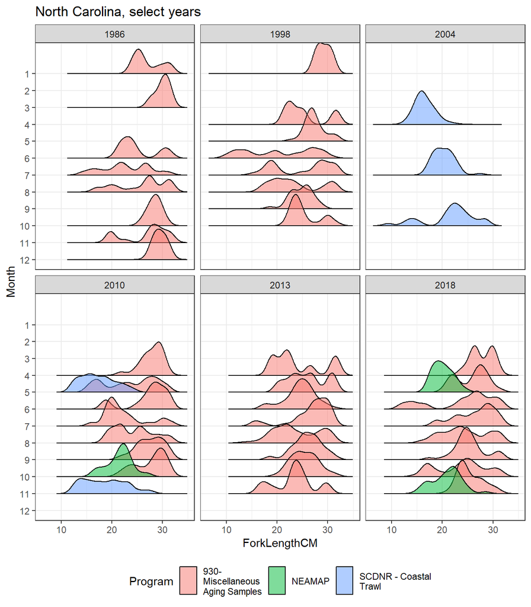

# 3 Indicator methods

## 3.1 Map of geogrpahy used for climate calculations

##### Figure 22

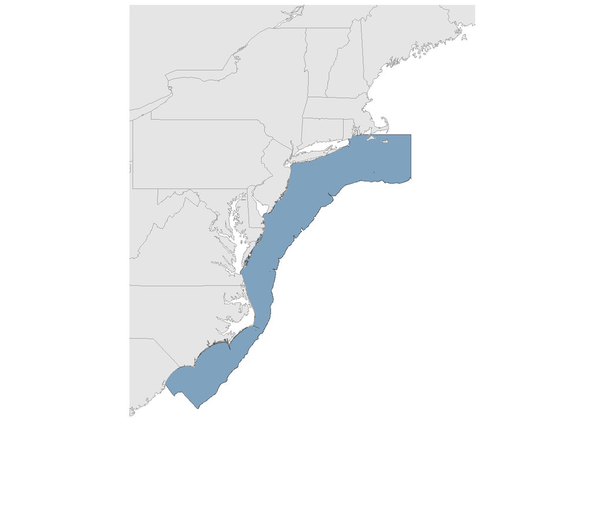

# 4 ESP time series

## 4.1 Ecosystem Indicators

### 4.1.1 Distribution

##### Figure 23

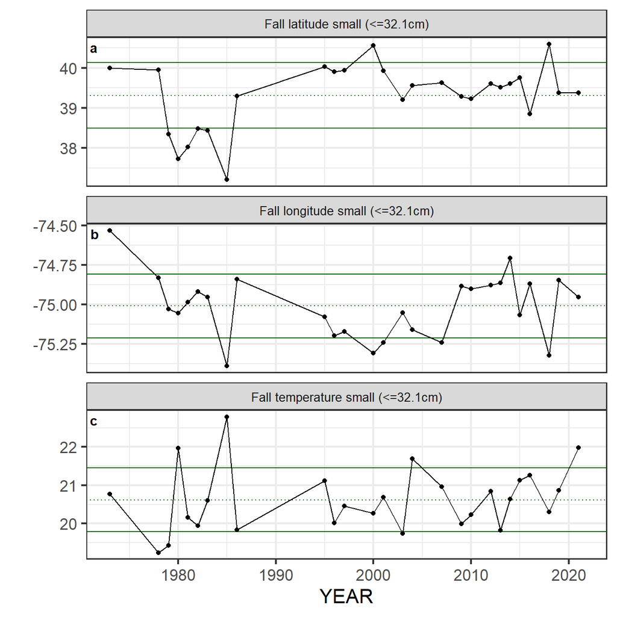

##### Figure 24

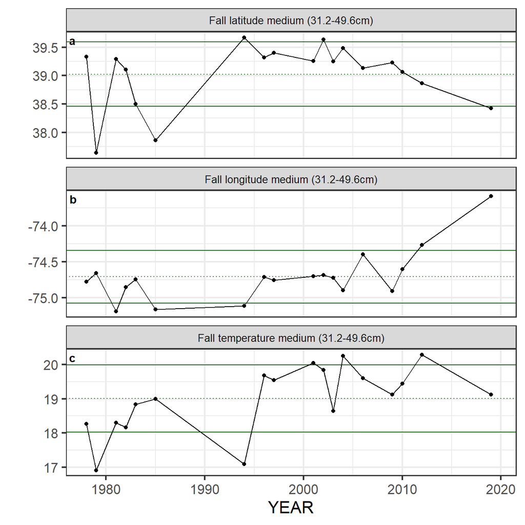

##### Figure 25

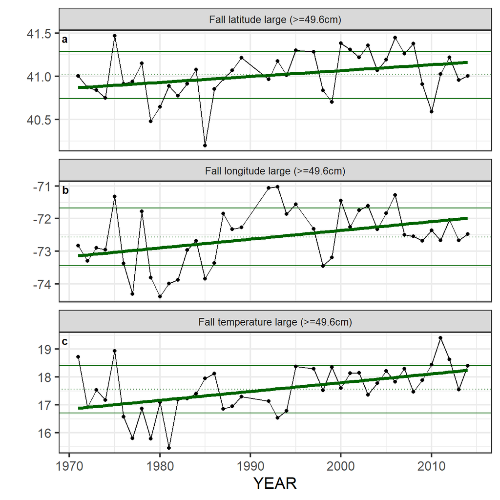

### 4.1.2 Climate

##### Figure 26

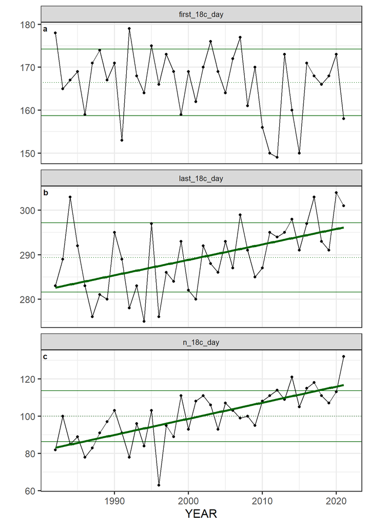

##### Figure 27

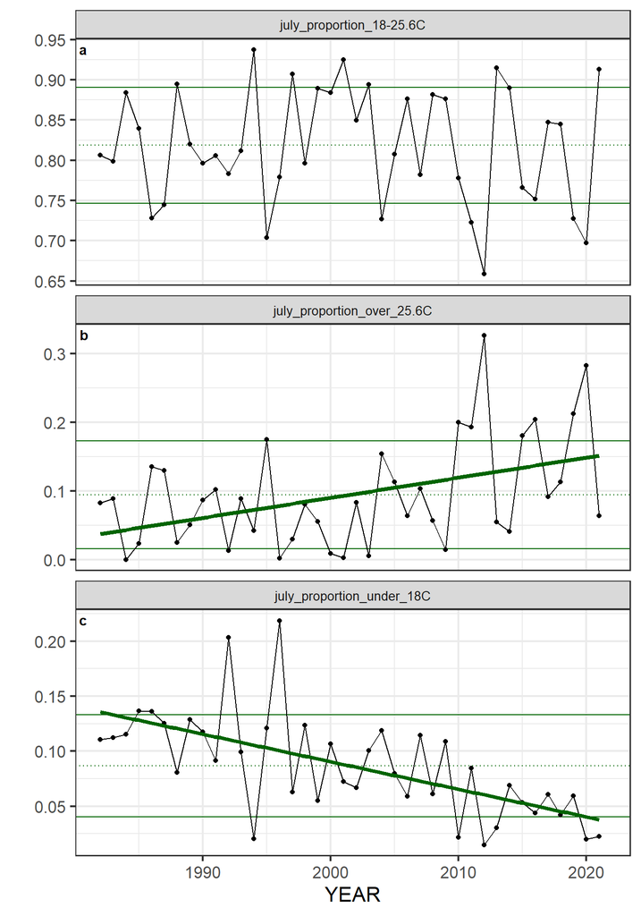

##### Figure 28

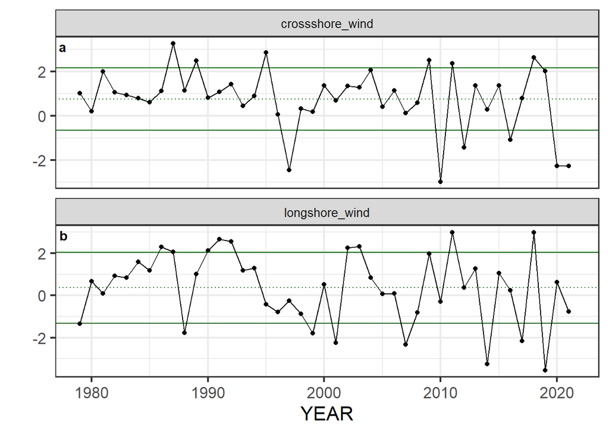

### 4.1.3 Natural mortality

##### Figure 29

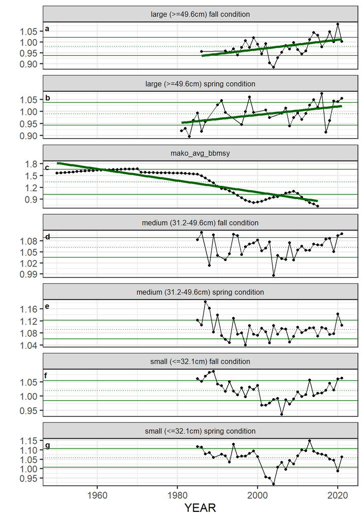

## 4.2 Socioeconomic Indicators

### 4.2.1 Recreational

##### Figure 30

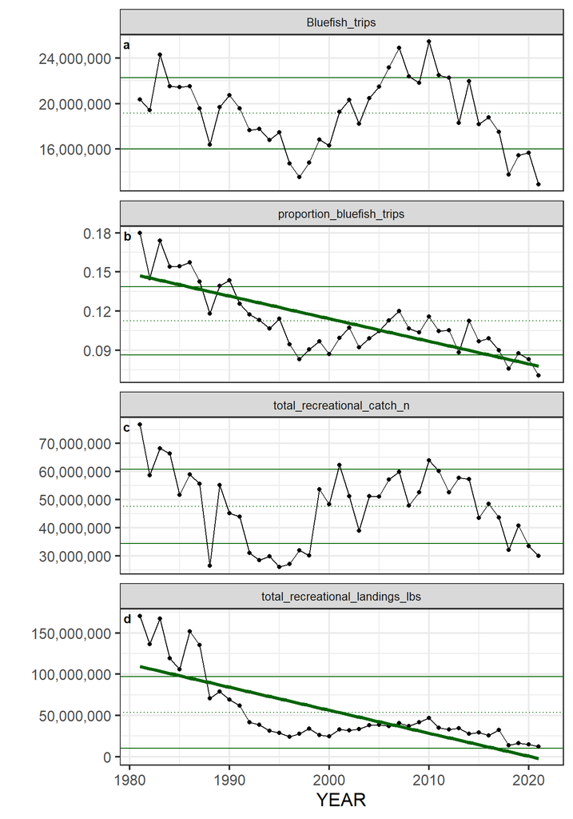

Figure 30. Number of directed recreational bluefish trips from 1981-2021. The proportion of directed recreational bluefish trips relative to other directed trips from 1981-2021. Total recreational bluefish catch in number of fish from 1981-2021. Total recreational bluefish landings (lbs) from 1981-2021

### 4.2.2 Commercial

##### Figure 31

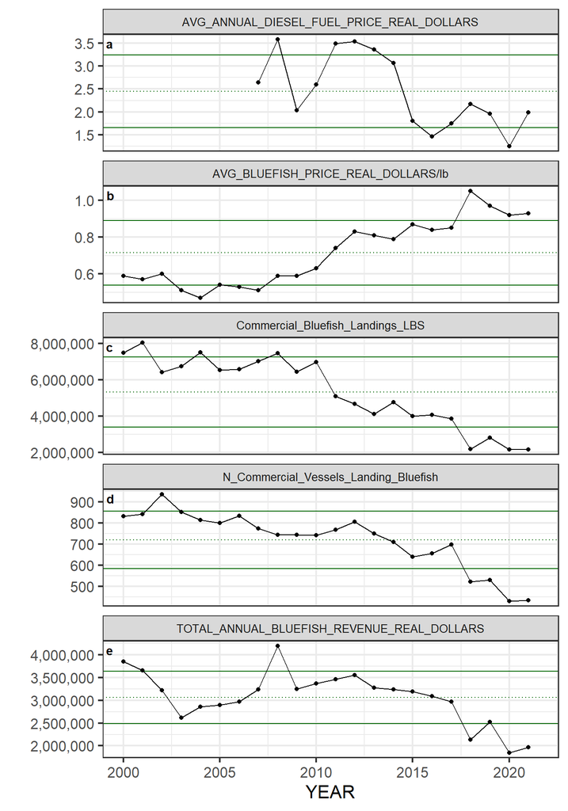

Figure 31. Average annual ultra-low-sulfur number 2 diesel fuel prices in 2021 constant U.S. dollars from 2007-2021. Ex-vessel bluefish prices ($/lb) from 2000-2021 in 2021 constant U.S. dollars. Ex-vessel bluefish prices ($/lb) from 2000-2021 in 2021 constant U.S. dollars. Commercial bluefish landings (lbs.) from 2000-2021. Number of commercial vessels landing bluefish from 2000-2021. Total annual commercial bluefish revenue in 2021 constant U.S. dollars from 2000-2021.

### 4.2.3 Community

##### Figure 32

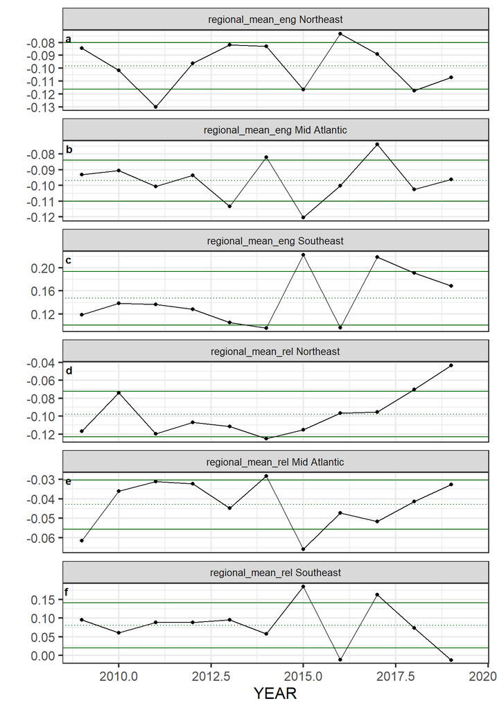

Figure 32. Average annual recreational engagement scores for the Northeast region from 2009-2019. Average annual recreational engagement scores for the Mid-Atlantic region from 2009-2019. Average annual recreational engagement scores for the Southeast region from 2009-2019. Average annual recreational reliance scores for the Northeast region from 2009-2019. Average annual recreational reliance scores for the Mid-Atlantic region from 2009-2019. Average annual recreational reliance scores for the Southeast region from 2009-2019.